# Bank Client Churn Prediction

### Tuning models

In this section we will find best hyper parameters for our models. The hyperparameters of machine learning algorithms let you fine-tune the algorithm’s behavior to work best with your data. Parameters, discovered by a learning method, are the model’s internal coefficients or weights; hyperparameters are different. Hyperparameters, in contrast to parameters, are practitioner-specified during model setup. Knowing what values to use for the hyperparameters of a particular algorithm on a specific dataset can be difficult, hence it is standard practice to employ random or grid search algorithms to try out a variety of hyperparameter values. The longer it takes to fine-tune an algorithm, the more hyperparameters it has. Selecting a small group of model hyperparameters to search or tweak is thus preferable. The hyperparameters in a model are not all of equal importance. A machine learning algorithm’s behavior and, by extension, its efficiency, may be drastically altered by adjusting certain hyperparameters.

One can plot a classification model’s accuracy against the area under the receiver operating characteristic (ROC) curve in order to get a visual representation of how well the model works across a range of thresholds. ROC stands for receiver operating characteristic. The phrase “Area under the ROC Curve” is what the acronym AUC stands for. Therefore, the area under the whole ROC curve in two dimensions is what is meant to be measured by the term “AUC.” It is possible to analyze a logistic regression model multiple times with different classification criteria in order to obtain the points on a ROC curve; however, doing so would be inefficient. We are fortunate enough to have access to these data thanks to an efficient sorting-based method known as AUC. The roc_auc value will be used to select the hyper-parameters.

#### Logistic regression

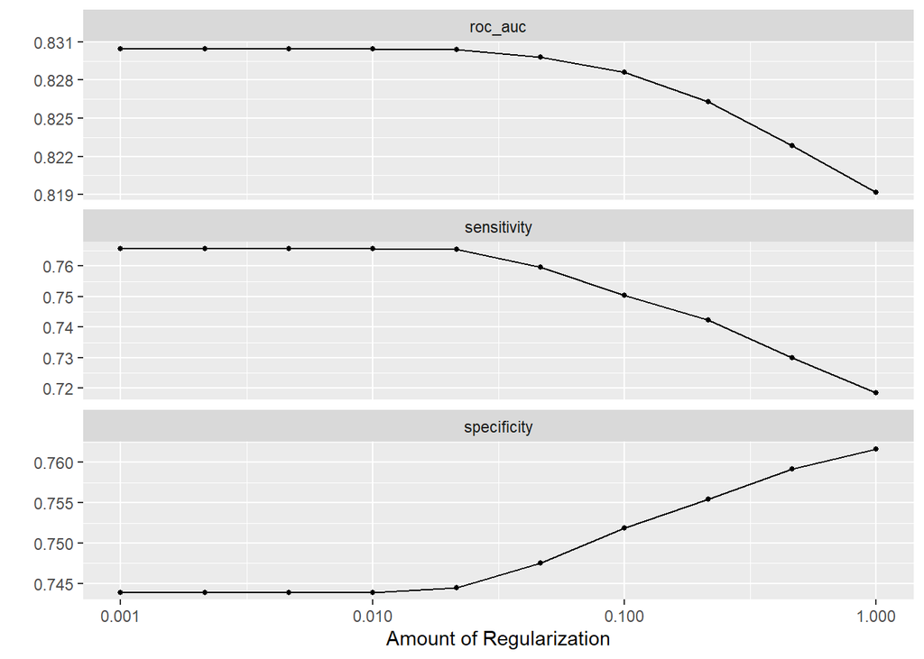

```r
#metrics we will use for finetuning, for this task I chose sensitivity, specificity and area under the ROC curve
met <- metric_set(sensitivity, specificity, roc_auc)

# tuning parameters from 0.001 to 1
grid <- tibble(penalty = 10^seq(-3, 0, length.out = 10))

# traing our model on cv folds
lr_res <- w_log %>%
  tune_grid(resamples = folds, grid = grid, metrics = met)

autoplot(lr_res)
```

To have superior stability of outcomes for correlated data and data with a large number of variables relative to the sample size, regression models are typically penalized. Oftentimes, penalized regression models are chosen over more standard selection techniques.Generally, it is best to have higher values with anything ROC curve related. Therefore, to maximize ROC_AUC lets choose penalty 0.01, since if we go any higher the values start to decrease. We can now proceed to fit whole training data on that model.